# Final Project Analysis Classification

Jason Booth

In this section, several classification algorithms will be applied the survey from 2011 to see if there is a classifiable relationship between survey responses and these categories. These models will be run only on the 2011 dataset because it has the most data of the surveys collected. Each model will be tuned and then compared against each other in terms of accuracy to see which one is the best fit.

Read data from CSV file.

```r
happyData11 <- read.csv("C:\\Users\\Jason\\Documents\\R_Notebooks\\FinalProject\\data\\CleanData\\CleanHappyData11.csv")
happyData11
```

| age | how_happy_do_you_feel_right_now | how_long_have_you_lived_here | how_satisfied_are_you_with_somerville_as_a_place_to_live | how_satisfied_are_you_with_your_life_in_general | marital_status_2011 | annual_household_income | gender_2011 | how_similar_are_you_to_other_people_you_know_2011 | seek_advice_or_decide_for_yourself_2011 | effectiveness_of_the_local_police_2011_2013 | beauty_or_physical_setting_2011 | the_availability_of_affordable_housing_2011 | race |
| --- | --- | --- | --- | --- | --- | --- | --- | --- | --- | --- | --- | --- | --- |
| 4.468925 | 8.000000 | 2.127517 | 7.590624 | 8.000000 | Single, Never Married | 7.096866 | Female | 6.00000 | 5.000000 | 7.384444 | 3.216941 | 2.962571 | Mixed |
| 7.000000 | 10.000000 | 4.000000 | 7.590624 | 10.000000 | Widowed | 1.000000 | Female | 10.00000 | 8.000000 | 7.384444 | 3.216941 | 2.962571 | Black/African American |
| 7.000000 | 10.000000 | 4.000000 | 4.000000 | 10.000000 | Married | 7.096866 | Male | 4.00000 | 10.000000 | 6.000000 | 3.000000 | 2.000000 | White |
| 3.000000 | 10.000000 | 1.000000 | 9.000000 | 10.000000 | Single, Never Married | 5.000000 | Male | 8.00000 | 7.000000 | 8.000000 | 4.000000 | 2.962571 | White |
| 7.000000 | 10.000000 | 4.000000 | 10.000000 | 10.000000 | Married | 1.000000 | Male | 10.00000 | 10.000000 | 10.000000 | 4.000000 | 4.000000 | White |
| 3.000000 | 8.000000 | 1.000000 | 9.000000 | 9.000000 | Single, Never Married | 8.000000 | Female | 7.00000 | 2.000000 | 10.000000 | 5.000000 | 5.000000 | White |
| 7.000000 | 7.000000 | 4.000000 | 8.000000 | 7.000000 | Married | 2.000000 | Male | 7.00000 | 7.000000 | 8.000000 | 3.000000 | 2.000000 | White |
| 7.000000 | 9.000000 | 4.000000 | 10.000000 | 7.000000 | Divorced | 6.000000 | Female | 6.00000 | 9.000000 | 10.000000 | 2.000000 | 2.962571 | White |
| 3.000000 | 4.000000 | 1.000000 | 6.000000 | 4.000000 | Single, Never Married | 3.000000 | Male | 8.00000 | 6.000000 | 6.000000 | 4.000000 | 2.000000 | White |
| 3.000000 | 8.000000 | 1.000000 | 9.000000 | 8.000000 | Married | 6.000000 | Male | 7.00000 | 7.000000 | 8.000000 | 4.000000 | 2.000000 | White |

[output cut: 990 more lines]

Use exploratory graphs to visualize disributions of marital status factor variable. At first glance it doesn’t appear that there is a clear classification.

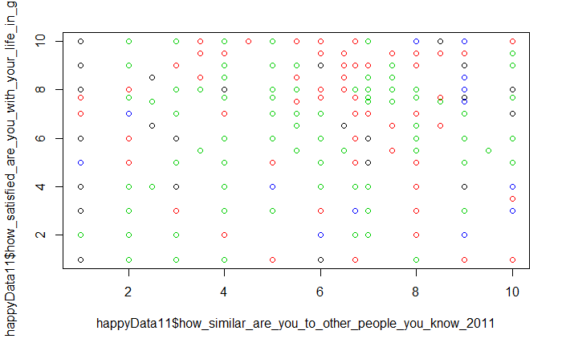

```r
plot(happyData11$how_similar_are_you_to_other_people_you_know_2011, happyData11$how_satisfied_are_you_with_your_life_in_general, col=happyData11$marital_status_2011)
```

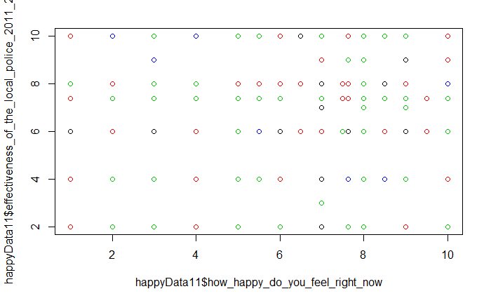

```r
plot(happyData11$how_happy_do_you_feel_right_now, happyData11$effectiveness_of_the_local_police_2011_2013, col=happyData11$marital_status_2011)
```

The dataset is reduced to only numeric features and normalized using the caret package. Normalization before feeding the data into a model is important because some models are sensitive to dispairities in scale of different features. For example, KNN uses Eauclidean distance for classification, and if one feature is much larger than another, it can become dominant in deciding classification of points.

```r
library(caret)
normalizedHappyData11Features <- subset(happyData11, select=-c(race, gender_2011, marital_status_2011))
normalizedHappyData11Features <- predict(preProcess(normalizedHappyData11Features, method = "range"), normalizedHappyData11Features)
happyData11Labels <- happyData11$marital_status_2011
normalizedHappyData11Features
```

|  | age | how_happy_do_you_feel_right_now | how_long_have_you_lived_here | how_satisfied_are_you_with_somerville_as_a_place_to_live | how_satisfied_are_you_with_your_life_in_general | annual_household_income | how_similar_are_you_to_other_people_you_know_2011 | seek_advice_or_decide_for_yourself_2011 | effectiveness_of_the_local_police_2011_2013 | beauty_or_physical_setting_2011 | the_availability_of_affordable_housing_2011 |
| --- | --- | --- | --- | --- | --- | --- | --- | --- | --- | --- | --- |
| 1 | 0.5781541 | 0.7777778 | 0.3758389 | 0.7322915 | 0.7777778 | 0.6774295 | 0.5555556 | 0.5000000 | 0.6730555 | 0.2463268 | 0.32709510 |
| 2 | 1.0000000 | 1.0000000 | 1.0000000 | 0.7322915 | 1.0000000 | 0.0000000 | 1.0000000 | 0.8000000 | 0.6730555 | 0.2463268 | 0.32709510 |
| 3 | 1.0000000 | 1.0000000 | 1.0000000 | 0.3333333 | 1.0000000 | 0.6774295 | 0.3333333 | 1.0000000 | 0.5000000 | 0.2222222 | 0.16666667 |
| 4 | 0.3333333 | 1.0000000 | 0.0000000 | 0.8888889 | 1.0000000 | 0.4444444 | 0.7777778 | 0.7000000 | 0.7500000 | 0.3333333 | 0.32709510 |
| 5 | 1.0000000 | 1.0000000 | 1.0000000 | 1.0000000 | 1.0000000 | 0.0000000 | 1.0000000 | 1.0000000 | 1.0000000 | 0.3333333 | 0.50000000 |
| 6 | 0.3333333 | 0.7777778 | 0.0000000 | 0.8888889 | 0.8888889 | 0.7777778 | 0.6666667 | 0.2000000 | 1.0000000 | 0.4444444 | 0.66666667 |
| 7 | 1.0000000 | 0.6666667 | 1.0000000 | 0.7777778 | 0.6666667 | 0.1111111 | 0.6666667 | 0.7000000 | 0.7500000 | 0.2222222 | 0.16666667 |
| 8 | 1.0000000 | 0.8888889 | 1.0000000 | 1.0000000 | 0.6666667 | 0.5555556 | 0.5555556 | 0.9000000 | 1.0000000 | 0.1111111 | 0.32709510 |
| 9 | 0.3333333 | 0.3333333 | 0.0000000 | 0.5555556 | 0.3333333 | 0.2222222 | 0.7777778 | 0.6000000 | 0.5000000 | 0.3333333 | 0.16666667 |
| 10 | 0.3333333 | 0.7777778 | 0.0000000 | 0.8888889 | 0.7777778 | 0.5555556 | 0.6666667 | 0.7000000 | 0.7500000 | 0.3333333 | 0.16666667 |

[output cut: 990 more lines]

Next, PCA is used to reduce the dimensionality of our data. PCA is often used when there are thousands of different features in a dataset and you would like to reduce them to only features that really differ. Although it is not really necessary to perform in this case, it is used as an exercise to get used to the mechanics of implementation.

PCA works by projecting the original features onto a smaller dimensional space made up of combinations of the original features. The plot below shows how significant each new vector is in determining the variation of the data after the projection. If a feature contains little variation, it can be eliminated without losing much information about the data.

```r
pcaFit <- princomp(normalizedHappyData11Features)
summary(pcaFit)
```

```
Importance of components:
                          Comp.1    Comp.2    Comp.3     Comp.4     Comp.5     Comp.6     Comp.7     Comp.8     Comp.9
Standard deviation     0.4535794 0.3356045 0.2500985 0.22905832 0.20827686 0.19033144 0.16641838 0.15579425 0.15002529
Proportion of Variance 0.3408994 0.1866272 0.1036434 0.08693841 0.07187893 0.06002617 0.04589043 0.04021818 0.03729482
Cumulative Proportion  0.3408994 0.5275266 0.6311700 0.71810845 0.78998738 0.85001354 0.89590397 0.93612215 0.97341697
                          Comp.10    Comp.11
Standard deviation     0.09598346 0.08264474
Proportion of Variance 0.01526555 0.01131749
Cumulative Proportion  0.98868251 1.00000000
```

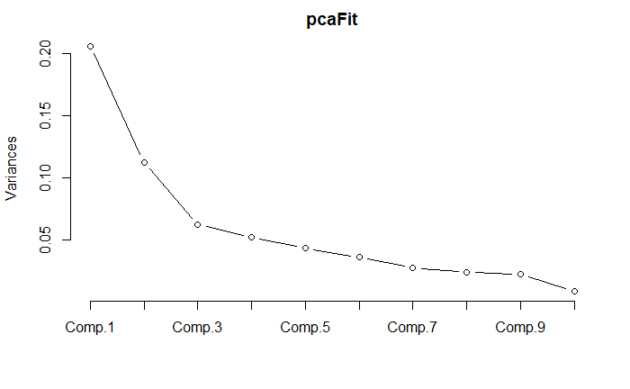

```r
screeplot(pcaFit, type="lines")
```

Based on the above plot, there appears to be a dropoff after the 9th component. These components are used to transform the original data into a new, lower dimensional space without losing much information about the original data.

```r
topNineComponents = pcaFit$loadings[,1:9]
pcaHappyDataFeatures <- as.data.frame(as.matrix(normalizedHappyData11Features) %*% topNineComponents)
pcaHappyDataFeatures
```

|  | Comp.1 | Comp.2 | Comp.3 | Comp.4 | Comp.5 | Comp.6 | Comp.7 | Comp.8 | Comp.9 |
| --- | --- | --- | --- | --- | --- | --- | --- | --- | --- |
| 1 | 0.68947983 | -1.6496999 | 0.4581265579 | -0.2837717939 | 0.545475768 | 0.154126247 | 2.183276e-01 | -0.0033252481 | 3.384671e-02 |
| 2 | 1.57166843 | -2.0253178 | -0.0721843964 | -0.2871526149 | 0.097850098 | 0.172737355 | 3.109326e-01 | 0.0258411154 | 1.686696e-02 |
| 3 | 1.45755252 | -1.6061507 | 0.6349668875 | -0.7670916603 | 0.235331987 | -0.194592897 | 3.405118e-01 | 0.2873796516 | 6.696440e-02 |
| 4 | 0.33509663 | -2.1072863 | 0.1435422698 | -0.3995210629 | 0.419771610 | 0.154751782 | 1.624177e-01 | -0.0214032960 | -8.303916e-02 |
| 5 | 1.63255815 | -2.2634906 | -0.2309737255 | -0.4301485123 | 0.455641830 | 0.281110205 | 2.167501e-01 | -0.0092201837 | 1.906575e-02 |
| 6 | 0.23267608 | -1.9545442 | 0.3855478821 | 0.0119912202 | 0.896253090 | 0.312227656 | 1.215867e-01 | 0.0433761261 | 2.217443e-01 |
| 7 | 1.53497237 | -1.5256868 | 0.0025430365 | -0.2877926383 | 0.413664191 | 0.198020409 | 2.817525e-01 | -0.0390361232 | -1.490196e-01 |
| 8 | 1.52287357 | -1.8105760 | 0.3100972187 | -0.5349091453 | 0.808318325 | 0.197238113 | 2.189099e-01 | -0.0172617210 | -8.960502e-02 |
| 9 | 0.32170691 | -1.1668332 | -0.0564184687 | -0.3444154741 | 0.237283549 | 0.560124020 | 1.610070e-01 | -0.1350659211 | -1.283872e-01 |
| 10 | 0.31889672 | -1.8055879 | 0.2349028515 | -0.4508249515 | 0.528431846 | 0.253480368 | 1.511122e-01 | -0.0785119151 | -2.307439e-01 |

[output cut: 990 more lines]

Split up the data into training and testing subsets. An 80 - 20 split is used.

```r
splitInidicies <- createDataPartition(y = pcaHappyDataFeatures$Comp.1, p= 0.8, list = FALSE)
training <- pcaHappyDataFeatures[splitInidicies,]
testing <- pcaHappyDataFeatures[-splitInidicies,]
trainingLabels <- happyData11[splitInidicies, "marital_status_2011"]
testingLabels <- happyData11[-splitInidicies, "marital_status_2011"]
nrow(training)
```

```
[1] 4935
```

```r
nrow(testing)
```

```
[1] 1232
```

To build and test each model we will use the caret package. This package exposes a really nice API which will tune the hyper-parameters of each model for you using cross-validation. Then we are able to test the models against each other using our test set.

This model creates and trains a knn model using 10 fold cross validation and 10 separate tries for k. A plot of the tuning of the value for k can be seen below.

```r
knnCtrl <- trainControl(method = "cv", number = 10)
knnFit <- train(training, trainingLabels, method = "knn",
 trControl=knnCtrl,
 tuneLength = 10) # number of k's to use
knnFit
```

```
k-Nearest Neighbors

4935 samples
   9 predictor
   4 classes: 'Divorced', 'Married', 'Single, Never Married', 'Widowed'

No pre-processing
Resampling: Cross-Validated (10 fold)
Summary of sample sizes: 4441, 4442, 4441, 4441, 4441, 4441, ...
Resampling results across tuning parameters:

  k   Accuracy   Kappa
   5  0.5728511  0.2810496
   7  0.5738595  0.2754764
   9  0.5750729  0.2744881
  11  0.5835802  0.2850336
  13  0.5821682  0.2806164
  15  0.5819645  0.2767141
  17  0.5807442  0.2726540
  19  0.5815568  0.2732681
  21  0.5841904  0.2773918
  23  0.5833823  0.2744678

Accuracy was used to select the optimal model using the largest value.
The final value used for the model was k = 21.
```

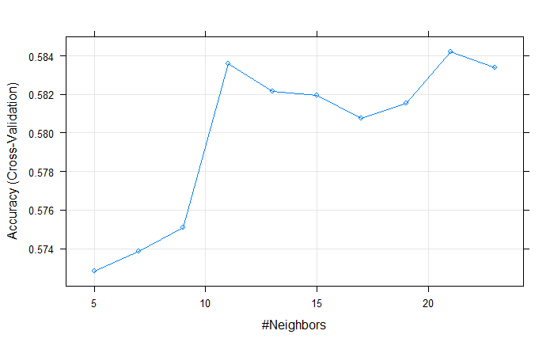

```r
plot(knnFit)
```

Next a naive bayes model is fit to the data. There is not the same concept of hyperparameters in this model, just one tuning parameter that is changed during training called a kernel. When we covered NB in class we discussed discretizing continuous data so that it could be put into a Naive Bayes model. Another method is to estimate a continuous distribution for the prior distribution using something called KDE or Kernel Density Estimation. Essentially this will assign each point a small normal distribution and smooth them out into a total continuous distribution that can sometimes approximate better than a histogram. In this case, it appears that using a kernel has slightly better performance.

```r
nbCtrl <- trainControl(method = "cv", number = 10)
nbFit <- train(training, trainingLabels, method = "naive_bayes",
 trControl=nbCtrl)
nbFit
```

```
Naive Bayes

4935 samples
   9 predictor
   4 classes: 'Divorced', 'Married', 'Single, Never Married', 'Widowed'

No pre-processing
Resampling: Cross-Validated (10 fold)
Summary of sample sizes: 4441, 4441, 4442, 4442, 4441, 4442, ...
Resampling results across tuning parameters:

  usekernel  Accuracy   Kappa
  FALSE      0.5645490  0.2677037
   TRUE      0.5805528  0.2970564

Tuning parameter 'laplace' was held constant at a value of 0
Tuning parameter 'adjust' was held constant at a value of 1
Accuracy was used to select the optimal model using the largest value.
The final values used for the model were laplace = 0, usekernel = TRUE and adjust = 1.
```

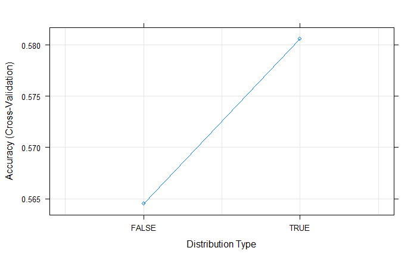

```r
plot(nbFit)
```

```r
grid <- expand.grid(C = c(0.25, 0.5, 1))
svmCtrl <- trainControl(method = "cv", number = 5)
svmFit <- train(training, trainingLabels, method = "svmLinear",
 trControl=svmCtrl,
 tuneGrid = grid,
 tuneLength = 3)
svmFit
```

```
Support Vector Machines with Linear Kernel

4935 samples
   9 predictor
   4 classes: 'Divorced', 'Married', 'Single, Never Married', 'Widowed'

No pre-processing
Resampling: Cross-Validated (5 fold)
Summary of sample sizes: 3948, 3948, 3948, 3948, 3948
Resampling results across tuning parameters:

  C     Accuracy   Kappa
  0.25  0.5669706  0.2265697
  0.50  0.5669706  0.2267204
  1.00  0.5667680  0.2268420

Accuracy was used to select the optimal model using the largest value.
The final value used for the model was C = 0.25.
```

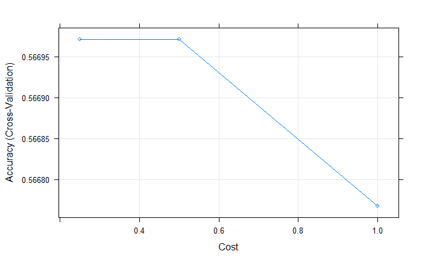

```r
plot(svmFit)
```

Another form of svm called radial SVM uses a non-linear decision boundary. This form will project the data into a higher dimensional space, create a hyperplane in that space diving your data, and then project down the decision boundary onto the original space. The same approach was used to reduce the cross-validation size and tuning length for performance reasons.

```r
svmRadCtrl <- trainControl(method = "cv", number = 5)
svmRadFit <- train(training, trainingLabels, method = "svmRadial",
 trControl=svmRadCtrl,
 tuneLength = 3)
svmRadFit
```

```
Support Vector Machines with Radial Basis Function Kernel

4935 samples
   9 predictor
   4 classes: 'Divorced', 'Married', 'Single, Never Married', 'Widowed'

No pre-processing
Resampling: Cross-Validated (5 fold)
Summary of sample sizes: 3948, 3948, 3948, 3948, 3948
Resampling results across tuning parameters:

  C     Accuracy   Kappa
  0.25  0.5811550  0.2490566
  0.50  0.5864235  0.2677958
  1.00  0.5935157  0.2889654

Tuning parameter 'sigma' was held constant at a value of 0.08755165
Accuracy was used to select the optimal model using the largest value.
The final values used for the model were sigma = 0.08755165 and C = 1.
```

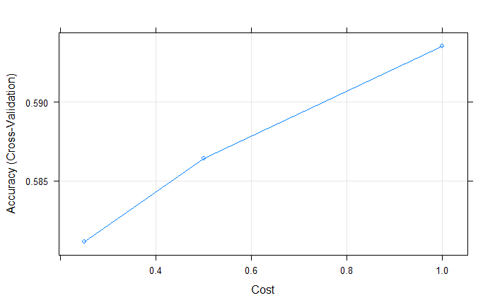

```r
plot(svmRadFit)
```

If svm fits the data well, there should be a small number of “support vectors” which influence the decision boundary. As we can see below, the number of support vector is quite high, which shows that the models are probably not a good fit for the data.

```r
svmFit$finalModel
```

```
Support Vector Machine object of class "ksvm"

SV type: C-svc  (classification)
 parameter : cost C = 0.25

Linear (vanilla) kernel function.

Number of Support Vectors : 3981

Objective Function Value : -212.5 -212.5 -108.0546 -783.4927 -120 -114.8359
Training error : 0.432421
```

```r
svmRadFit$finalModel
```

```
Support Vector Machine object of class "ksvm"

SV type: C-svc  (classification)
 parameter : cost C = 1

Gaussian Radial Basis kernel function.
 Hyperparameter : sigma =  0.0875516491715281

Number of Support Vectors : 3930

Objective Function Value : -790.6975 -785.7657 -358.46 -2806.354 -415.8192 -403.8178
Training error : 0.357649
```

One last method of classification is used as a practice exercise, although it will not be used on the testing data. A decision tree is unique among other classifiers because it is very interpretable and can lead to discoveries about the data that were unknown. It creates a tree of decision boundaries for each feature leading to a classification leaf at the bottom of each branch. Below, a tree is created on the non-normalized, non-pca data and printed to see what the tree might look like. Although some of these values like age and income are ordinal and don’t hold physical meaning, it can be seen how a model like this would be useful.

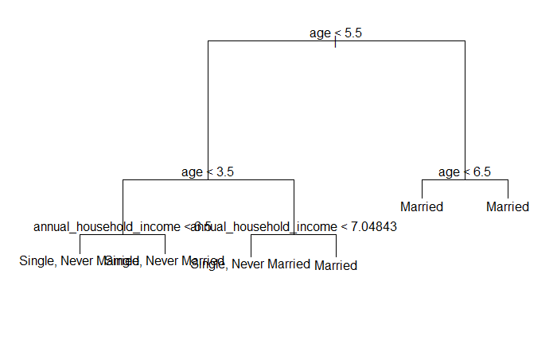

```r
# Commented out for the graders convenience
# install.packages("tree")
library(tree)
regTreeModel <- tree(marital_status_2011 ~ . - race - gender_2011, data=happyData11)
plot(regTreeModel); text(regTreeModel)
```

After the models have been created and trained using cross-validation, the test dataset is used to determine the final accuracy of each model.

```r
knnPred <- predict(knnFit, testing)
confusionMatrix(knnPred, testingLabels)
```

```
Confusion Matrix and Statistics

                       Reference
Prediction              Divorced Married Single, Never Married Widowed
  Divorced                     2       4                     9       6
  Married                     54     243                   154      32
  Single, Never Married       37     199                   439      14
  Widowed                     10       7                     7      15

Overall Statistics

               Accuracy : 0.5674
                 95% CI : (0.5392, 0.5953)
    No Information Rate : 0.4943
    P-Value [Acc > NIR] : 1.645e-07

                  Kappa : 0.2492
 Mcnemar's Test P-Value : 2.941e-16

Statistics by Class:

                     Class: Divorced Class: Married Class: Single, Never Married Class: Widowed
Sensitivity                 0.019417         0.5364                       0.7209        0.22388
Specificity                 0.983171         0.6919                       0.5987        0.97940
Pos Pred Value              0.095238         0.5031                       0.6372        0.38462
Neg Pred Value              0.916598         0.7196                       0.6869        0.95641
Prevalence                  0.083604         0.3677                       0.4943        0.05438
Detection Rate              0.001623         0.1972                       0.3563        0.01218
Detection Prevalence        0.017045         0.3920                       0.5593        0.03166
Balanced Accuracy           0.501294         0.6142                       0.6598        0.60164
```

```r
nbPred <- predict(nbFit, testing)
confusionMatrix(nbPred, testingLabels)
```

```
Confusion Matrix and Statistics

                       Reference
Prediction              Divorced Married Single, Never Married Widowed
  Divorced                    15      12                    17       9
  Married                     47     233                   152      21
  Single, Never Married       26     181                   417       7
  Widowed                     15      27                    23      30

Overall Statistics

               Accuracy : 0.5641
                 95% CI : (0.5359, 0.592)
    No Information Rate : 0.4943
    P-Value [Acc > NIR] : 5.380e-07

                  Kappa : 0.2782
 Mcnemar's Test P-Value : 2.812e-06

Statistics by Class:

                     Class: Divorced Class: Married Class: Single, Never Married Class: Widowed
Sensitivity                  0.14563         0.5143                       0.6847        0.44776
Specificity                  0.96634         0.7176                       0.6565        0.94421
Pos Pred Value               0.28302         0.5143                       0.6609        0.31579
Neg Pred Value               0.92536         0.7176                       0.6805        0.96746
Prevalence                   0.08360         0.3677                       0.4943        0.05438
Detection Rate               0.01218         0.1891                       0.3385        0.02435
Detection Prevalence         0.04302         0.3677                       0.5122        0.07711
Balanced Accuracy            0.55599         0.6160                       0.6706        0.69598
```

```r
svmPred <- predict(svmFit, testing)
confusionMatrix(svmPred, testingLabels)
```

```
Confusion Matrix and Statistics

                       Reference
Prediction              Divorced Married Single, Never Married Widowed
  Divorced                     0       0                     0       0
  Married                     65     211                   154      56
  Single, Never Married       38     242                   455      11
  Widowed                      0       0                     0       0

Overall Statistics

               Accuracy : 0.5406
                 95% CI : (0.5123, 0.5687)
    No Information Rate : 0.4943
    P-Value [Acc > NIR] : 0.0006396

                  Kappa : 0.1732
 Mcnemar's Test P-Value : NA

Statistics by Class:

                     Class: Divorced Class: Married Class: Single, Never Married Class: Widowed
Sensitivity                   0.0000         0.4658                       0.7471        0.00000
Specificity                   1.0000         0.6470                       0.5329        1.00000
Pos Pred Value                   NaN         0.4342                       0.6099            NaN
Neg Pred Value                0.9164         0.6756                       0.6831        0.94562
Prevalence                    0.0836         0.3677                       0.4943        0.05438
Detection Rate                0.0000         0.1713                       0.3693        0.00000
Detection Prevalence          0.0000         0.3945                       0.6055        0.00000
Balanced Accuracy             0.5000         0.5564                       0.6400        0.50000
```

```r
svmRadPred <- predict(svmRadFit, testing)
confusionMatrix(svmRadPred, testingLabels)
```

```
Confusion Matrix and Statistics

                       Reference
Prediction              Divorced Married Single, Never Married Widowed
  Divorced                     3       4                     3       1
  Married                     49     254                   162      36
  Single, Never Married       42     192                   440      16
  Widowed                      9       3                     4      14

Overall Statistics

               Accuracy : 0.5771
                 95% CI : (0.549, 0.6049)
    No Information Rate : 0.4943
    P-Value [Acc > NIR] : 3.454e-09

                  Kappa : 0.2601
 Mcnemar's Test P-Value : < 2.2e-16

Statistics by Class:

                     Class: Divorced Class: Married Class: Single, Never Married Class: Widowed
Sensitivity                 0.029126         0.5607                       0.7225        0.20896
Specificity                 0.992914         0.6829                       0.5987        0.98627
Pos Pred Value              0.272727         0.5070                       0.6377        0.46667
Neg Pred Value              0.918100         0.7278                       0.6882        0.95591
Prevalence                  0.083604         0.3677                       0.4943        0.05438
Detection Rate              0.002435         0.2062                       0.3571        0.01136
Detection Prevalence        0.008929         0.4067                       0.5601        0.02435
Balanced Accuracy           0.511020         0.6218                       0.6606        0.59761
```

Overall there is not a clear winner in terms of which model performed best. All models were around 55-60% performant in terms of predicting marital status for the test dataset. This shows that there is probably not a clear correlation between marital status and responses on the survey. Despite the bad results, this was a great exercise in learning new api’s and exploring a real-world machine learning application.